# 02_staar_2016_2017_cleaning

## Join the meeting dataframes into one master

Using `dplyr::inner_joins` we will merge the numerator, denominator, and rate dataframes to compare and generate a master dataframe. For some reason I am still seeing negative values for some districts, so we will filtering only students that are > 0. I don’t see a situation where you can have negative students in the denominator (maybe leaving school?) but regardless I am making the assumption it is a clerical error and will be excluding it.

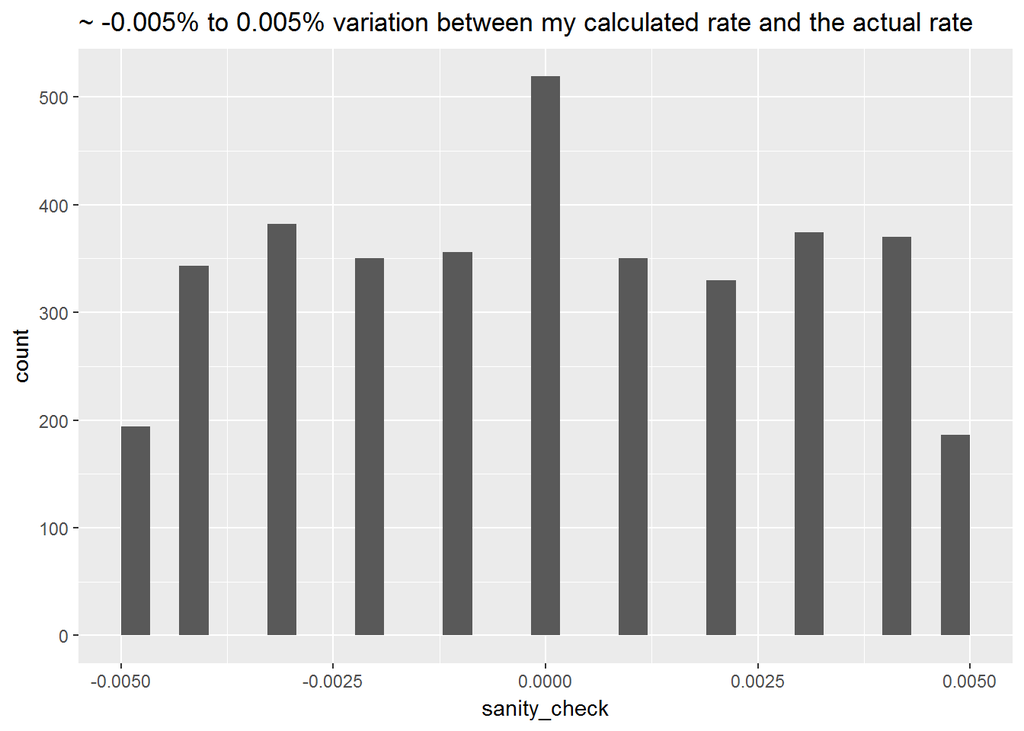

```r
meeting_df <- inner_join(meet_num, meet_denom, by = c("campus", "gradetype", "year_code", "group_code", "subject_code")) %>%
    rename(numer_students = number_of_students.x, denom_students = number_of_students.y) %>%
    select(-ends_with(".y"), - ends_with(".x")) %>%
    inner_join(meet_rate, by = c("campus", "gradetype", "year_code", "group_code", "subject_code")) %>%
    filter(numer_students > 0, denom_students > 0) %>%
    mutate(rate = numer_students/denom_students,
           given_rate = number_of_students/100) %>%
    select(-number_of_students)


# sanity check the rate vs given rate from the dataset
meeting_df %>%
    mutate(sanity_check = round(rate - given_rate, digits = 3)) %>%
    ggplot(aes(x = sanity_check)) +
    geom_histogram() +
    labs(title = "~ -0.005% to 0.005% variation between my calculated rate and the actual rate")
```

```r
# I'll take that as rate being == percentage!
```

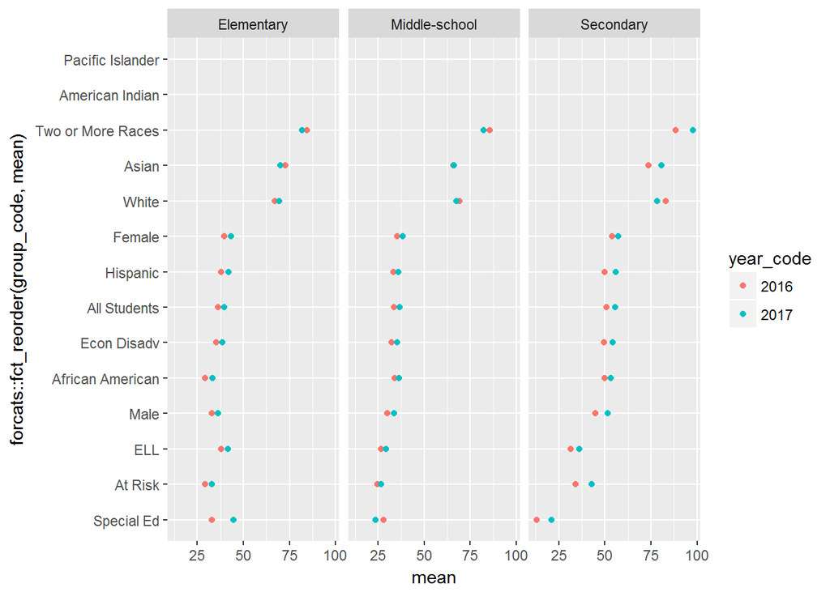

```r
# sanity check overall data w/ a basic graph
# I'm probably going to exclude pacific islander and American Indian from the final graph
# as there is substantial missing data or just no students in these racial categories
meet_rate %>%
  group_by(group_code, gradetype, year_code) %>%
  summarize(mean = mean(number_of_students, na.rm = T)) %>%
  ungroup %>%
  ggplot(aes(x = forcats::fct_reorder(group_code, mean), y = mean, group = group_code, color = year_code)) +
  geom_point() +
  coord_flip() +
  facet_grid(~gradetype)
```

```r
meet_rate %>%
  group_by(group_code, gradetype, year_code) %>%
  summarize(mean = mean(number_of_students, na.rm = T)) %>%
  ungroup %>%
    filter(is.na(mean))
```

```
## # A tibble: 12 x 4
##    group_code       gradetype     year_code  mean
##    <fct>            <fct>         <fct>     <dbl>
##  1 American Indian  Elementary    2016        NaN
##  2 American Indian  Elementary    2017        NaN
##  3 American Indian  Middle-school 2016        NaN
##  4 American Indian  Middle-school 2017        NaN
##  5 American Indian  Secondary     2016        NaN
##  6 American Indian  Secondary     2017        NaN
##  7 Pacific Islander Elementary    2016        NaN
##  8 Pacific Islander Elementary    2017        NaN
##  9 Pacific Islander Middle-school 2016        NaN
## 10 Pacific Islander Middle-school 2017        NaN
## 11 Pacific Islander Secondary     2016        NaN
## 12 Pacific Islander Secondary     2017        NaN
```